# ASSIGNMENT 4: UNSUPERVISED LEARNING

### Making the necessary imports

```python
import numpy as np
import pandas as pd
import matplotlib.pyplot as plt
import seaborn as sns
import scipy.stats as stat
from sklearn.svm import SVC
from sklearn.decomposition import PCA
from sklearn.metrics import confusion_matrix, classification_report, accuracy_score
from sklearn.model_selection import train_test_split, KFold, cross_val_score, GridSearchCV
from sklearn.linear_model import LinearRegression
from sklearn.preprocessing import MinMaxScaler

%matplotlib inline
```

## Q1 Data pre-processing – Perform all the necessary preprocessing on the data ready to be fed to an Unsupervised algorithm

## Ans1

### Read the data

```python
veh_df = pd.read_csv("vehicle.csv")
veh_df.info()
```

```
<class 'pandas.core.frame.DataFrame'>
RangeIndex: 846 entries, 0 to 845
Data columns (total 19 columns):
compactness                    846 non-null int64
circularity                    841 non-null float64
distance_circularity           842 non-null float64
radius_ratio                   840 non-null float64
pr.axis_aspect_ratio           844 non-null float64
max.length_aspect_ratio        846 non-null int64
scatter_ratio                  845 non-null float64
elongatedness                  845 non-null float64
pr.axis_rectangularity         843 non-null float64
max.length_rectangularity      846 non-null int64
scaled_variance                843 non-null float64
scaled_variance.1              844 non-null float64
scaled_radius_of_gyration      844 non-null float64
scaled_radius_of_gyration.1    842 non-null float64
skewness_about                 840 non-null float64
skewness_about.1               845 non-null float64
skewness_about.2               845 non-null float64
hollows_ratio                  846 non-null int64
class                          846 non-null object
dtypes: float64(14), int64(4), object(1)
memory usage: 125.7+ KB
```

### Observation

```
1. Apart from the target class, all other columns are numeric
2. 4 of the independent columns have all non-null values, all others (14) have some null values
```

### Let us add an index to the data to make it easier to update individual rows later

```python
for index, row in veh_df.iterrows():
    veh_df.at[index, "index_"] = index
veh_df.head()
```

|  | compactness | circularity | distance_circularity | radius_ratio | pr.axis_aspect_ratio | max.length_aspect_ratio | scatter_ratio | elongatedness | pr.axis_rectangularity | max.length_rectangularity | scaled_variance | scaled_variance.1 | scaled_radius_of_gyration | scaled_radius_of_gyration.1 | skewness_about | skewness_about.1 | skewness_about.2 | hollows_ratio | class | index_ |
| --- | --- | --- | --- | --- | --- | --- | --- | --- | --- | --- | --- | --- | --- | --- | --- | --- | --- | --- | --- | --- |
| 0 | 95 | 48.0 | 83.0 | 178.0 | 72.0 | 10 | 162.0 | 42.0 | 20.0 | 159 | 176.0 | 379.0 | 184.0 | 70.0 | 6.0 | 16.0 | 187.0 | 197 | van | 0.0 |
| 1 | 91 | 41.0 | 84.0 | 141.0 | 57.0 | 9 | 149.0 | 45.0 | 19.0 | 143 | 170.0 | 330.0 | 158.0 | 72.0 | 9.0 | 14.0 | 189.0 | 199 | van | 1.0 |
| 2 | 104 | 50.0 | 106.0 | 209.0 | 66.0 | 10 | 207.0 | 32.0 | 23.0 | 158 | 223.0 | 635.0 | 220.0 | 73.0 | 14.0 | 9.0 | 188.0 | 196 | car | 2.0 |
| 3 | 93 | 41.0 | 82.0 | 159.0 | 63.0 | 9 | 144.0 | 46.0 | 19.0 | 143 | 160.0 | 309.0 | 127.0 | 63.0 | 6.0 | 10.0 | 199.0 | 207 | van | 3.0 |
| 4 | 85 | 44.0 | 70.0 | 205.0 | 103.0 | 52 | 149.0 | 45.0 | 19.0 | 144 | 241.0 | 325.0 | 188.0 | 127.0 | 9.0 | 11.0 | 180.0 | 183 | bus | 4.0 |

## Treating null values

### Since the number of not null entities is low, We can assume that the dataset has a considerable number of rows that have all data. We want to use it to predict the missing entities. Let us filter out these non null rows

```python
veh_impute_df = veh_df[(veh_df["compactness"].isnull() == False) &
                      (veh_df["circularity"].isnull() == False) &
                      (veh_df["distance_circularity"].isnull() == False) &
                      (veh_df["radius_ratio"].isnull() == False) &
                      (veh_df["pr.axis_aspect_ratio"].isnull() == False) &
                      (veh_df["max.length_aspect_ratio"].isnull() == False) &
                      (veh_df["scatter_ratio"].isnull() == False) &
                      (veh_df["elongatedness"].isnull() == False) &
                      (veh_df["pr.axis_rectangularity"].isnull() == False) &
                      (veh_df["max.length_rectangularity"].isnull() == False) &
                      (veh_df["scaled_variance"].isnull() == False) &
                      (veh_df["scaled_variance.1"].isnull() == False) &
                      (veh_df["scaled_radius_of_gyration"].isnull() == False) &
                      (veh_df["scaled_radius_of_gyration.1"].isnull() == False) &
                      (veh_df["skewness_about"].isnull() == False) &
                      (veh_df["skewness_about.1"].isnull() == False) &
                      (veh_df["skewness_about.2"].isnull() == False) &
                      (veh_df["hollows_ratio"].isnull() == False)]
```

### Treating null values

#### We see four columns,["compactness", "max.length_aspect_ratio", "max.length_rectangularity", "hollows_ratio"], that have no null values. It would be a fair assumption to say that these could be core columns. Based on this assumption, let us see if they can predict the others

```python
##The base set(good data)
y = veh_impute_df["circularity"]
x = veh_impute_df[["compactness", "max.length_aspect_ratio", "max.length_rectangularity","hollows_ratio"]]
x_train, x_test, y_train, y_test = train_test_split(x, y, test_size = 0.4, random_state = 100)

#creating a linear regression
lin_reg = LinearRegression()
lin_reg.fit(x_train, y_train)
print(lin_reg.score(x_train, y_train))
print(lin_reg.score(x_test, y_test))
impute_x = veh_df[veh_df["circularity"].isnull()]
indice_x = np.array(impute_x["index_"])

##The set that needs to be predicted
impute_x = impute_x[["compactness", "max.length_aspect_ratio", "max.length_rectangularity","hollows_ratio"]]
pred = lin_reg.predict(impute_x)
print(pred)
i = 0

##Updating it back
for prediction in pred:
    indice = indice_x[i]
    veh_df.at[indice, "circularity"] = prediction
    i = i + 1
```

```
0.9433696905292912
0.9329775133366993
[54.65485222 53.45311984 43.27689753 42.28047724 55.23685784]
```

##### The prediction turned out to be very accurate 93%. This means that our assumption is correct. We can now proceed to predict all the missing entities one by one and update them back into the main dataframe

#### Predicting "scaled_radius_of_gyration"

```python
##The base set(good data)
y = veh_impute_df["scaled_radius_of_gyration"]
x = veh_impute_df[["compactness", "max.length_aspect_ratio", "max.length_rectangularity","hollows_ratio","circularity"]]
x_train, x_test, y_train, y_test = train_test_split(x, y, test_size = 0.3, random_state = 100)

#creating a linear regression
lin_reg = LinearRegression()
lin_reg.fit(x_train, y_train)
print(lin_reg.score(x_train, y_train))
print(lin_reg.score(x_test, y_test))

##The set that needs to be predicted
impute_x = veh_df[veh_df["scaled_radius_of_gyration"].isnull()]
indice_x = np.array(impute_x["index_"])
impute_x = impute_x[["compactness", "max.length_aspect_ratio", "max.length_rectangularity","hollows_ratio","circularity"]]
pred = lin_reg.predict(impute_x)
print(pred)
i = 0

##Updating it back
for prediction in pred:
    indice = indice_x[i]
    veh_df.at[indice, "scaled_radius_of_gyration"] = prediction
    i = i + 1
```

```
0.9178517990771242
0.9021737185317006
[162.10175344 169.56436937]
```

#### Predicting "scaled_variance.1"

```python
##The base set(good data)
y = veh_impute_df["scaled_variance.1"]
x = veh_impute_df[["compactness", "max.length_aspect_ratio", "max.length_rectangularity","hollows_ratio","circularity","scaled_radius_of_gyration"]]
x_train, x_test, y_train, y_test = train_test_split(x, y, test_size = 0.3, random_state = 100)

#creating a linear regression
lin_reg = LinearRegression()
lin_reg.fit(x_train, y_train)
print(lin_reg.score(x_train, y_train))
print(lin_reg.score(x_test, y_test))

##The set that needs to be predicted
impute_x = veh_df[veh_df["scaled_variance.1"].isnull()]
indice_x = np.array(impute_x["index_"])
impute_x = impute_x[["compactness", "max.length_aspect_ratio", "max.length_rectangularity","hollows_ratio","circularity","scaled_radius_of_gyration"]]
pred = lin_reg.predict(impute_x)
print(pred)
i = 0

##Updating it back

for prediction in pred:
    indice = indice_x[i]
    veh_df.at[indice, "scaled_variance.1"] = prediction
    i = i + 1
```

```
0.8438464019372233
0.8437560299505276
[682.99928383 712.95871914]
```

#### Predicting "pr.axis_rectangularity"

```python
##The base set(good data)
y = veh_impute_df["pr.axis_rectangularity"]
x = veh_impute_df[["compactness", "max.length_aspect_ratio", "max.length_rectangularity","hollows_ratio","circularity","scaled_radius_of_gyration","scaled_variance.1"]]

x_train, x_test, y_train, y_test = train_test_split(x, y, test_size = 0.3, random_state = 100)

#creating a linear regression
lin_reg = LinearRegression()
lin_reg.fit(x_train, y_train)
print(lin_reg.score(x_train, y_train))
print(lin_reg.score(x_test, y_test))

##The set that needs to be predicted
impute_x = veh_df[veh_df["pr.axis_rectangularity"].isnull()]
indice_x = np.array(impute_x["index_"])
impute_x = impute_x[["compactness", "max.length_aspect_ratio", "max.length_rectangularity","hollows_ratio","circularity","scaled_radius_of_gyration","scaled_variance.1"]]

pred = lin_reg.predict(impute_x)
print(pred)
i = 0

##Updating it back
for prediction in pred:
    indice = indice_x[i]
    veh_df.at[indice, "pr.axis_rectangularity"] = prediction
    i = i + 1
```

```
0.986561293043548
0.9855590926899332
[24.26106337 18.98274889 18.7271121 ]
```

#### Predicting "scatter_ratio"

```python
##The base set(good data)
y = veh_impute_df["scatter_ratio"]
x = veh_impute_df[["compactness", "max.length_aspect_ratio", "max.length_rectangularity","hollows_ratio","circularity","scaled_radius_of_gyration","scaled_variance.1","pr.axis_rectangularity"]]

x_train, x_test, y_train, y_test = train_test_split(x, y, test_size = 0.3, random_state = 100)

#creating a linear regression
lin_reg = LinearRegression()
lin_reg.fit(x_train, y_train)
print(lin_reg.score(x_train, y_train))
print(lin_reg.score(x_test, y_test))

##The set that needs to be predicted
impute_x = veh_df[veh_df["scatter_ratio"].isnull()]
indice_x = np.array(impute_x["index_"])
impute_x = impute_x[["compactness", "max.length_aspect_ratio", "max.length_rectangularity","hollows_ratio","circularity","scaled_radius_of_gyration","scaled_variance.1","pr.axis_rectangularity"]]

pred = lin_reg.predict(impute_x)
print(pred)
i = 0

##Updating it back
for prediction in pred:
    indice = indice_x[i]
    veh_df.at[indice, "scatter_ratio"] = prediction
    i = i + 1
```

```
0.9943769548332877
0.9946308046599123
[121.76444372]
```

#### Predicting "skewness_about.2"

```python
##The base set(good data)
y = veh_impute_df["skewness_about.2"]
x = veh_impute_df[["compactness", "max.length_aspect_ratio", "max.length_rectangularity","hollows_ratio","circularity","scaled_radius_of_gyration","scaled_variance.1","pr.axis_rectangularity","scatter_ratio"]]

x_train, x_test, y_train, y_test = train_test_split(x, y, test_size = 0.2, random_state = 100)

#creating a linear regression
lin_reg = LinearRegression()
lin_reg.fit(x_train, y_train)
print(lin_reg.score(x_train, y_train))
print(lin_reg.score(x_test, y_test))

##The set that needs to be predicted
impute_x = veh_df[veh_df["skewness_about.2"].isnull()]
indice_x = np.array(impute_x["index_"])
impute_x = impute_x[["compactness", "max.length_aspect_ratio", "max.length_rectangularity","hollows_ratio","circularity","scaled_radius_of_gyration","scaled_variance.1","pr.axis_rectangularity","scatter_ratio"]]

pred = lin_reg.predict(impute_x)
print(pred)
i = 0

##Updating it back
for prediction in pred:
    indice = indice_x[i]
    veh_df.at[indice, "skewness_about.2"] = prediction
    i = i + 1
```

```
0.885101932745877
0.8479913879567993
[199.17956886]
```

#### Predicting "elongatedness"

```python
##The base set(good data)
y = veh_impute_df["elongatedness"]
x = veh_impute_df[["compactness", "max.length_aspect_ratio", "max.length_rectangularity","hollows_ratio","circularity","scaled_radius_of_gyration","scaled_variance.1","pr.axis_rectangularity","scatter_ratio","skewness_about.2"]]

x_train, x_test, y_train, y_test = train_test_split(x, y, test_size = 0.2, random_state = 100)

#creating a linear regression
lin_reg = LinearRegression()
lin_reg.fit(x_train, y_train)
print(lin_reg.score(x_train, y_train))
print(lin_reg.score(x_test, y_test))

##The set that needs to be predicted
impute_x = veh_df[veh_df["elongatedness"].isnull()]
indice_x = np.array(impute_x["index_"])
impute_x = impute_x[["compactness", "max.length_aspect_ratio", "max.length_rectangularity","hollows_ratio","circularity","scaled_radius_of_gyration","scaled_variance.1","pr.axis_rectangularity","scatter_ratio","skewness_about.2"]]

pred = lin_reg.predict(impute_x)
print(pred)
i = 0

##Updating it back
for prediction in pred:
    indice = indice_x[i]
    veh_df.at[indice, "elongatedness"] = prediction
    i = i + 1
```

```
0.9907563990500493
0.9889082466823618
[41.42025525]
```

#### Predicting "scaled_variance"

```python
##The base set(good data)
y = veh_impute_df["scaled_variance"]
x = veh_impute_df[["compactness", "max.length_aspect_ratio", "max.length_rectangularity","hollows_ratio","circularity","scaled_radius_of_gyration","scaled_variance.1","pr.axis_rectangularity","scatter_ratio","skewness_about.2","elongatedness"]]

x_train, x_test, y_train, y_test = train_test_split(x, y, test_size = 0.2, random_state = 100)

#creating a linear regression
lin_reg = LinearRegression()
lin_reg.fit(x_train, y_train)
print(lin_reg.score(x_train, y_train))
print(lin_reg.score(x_test, y_test))

##The set that needs to be predicted
impute_x = veh_df[veh_df["scaled_variance"].isnull()]
indice_x = np.array(impute_x["index_"])
impute_x = impute_x[["compactness", "max.length_aspect_ratio", "max.length_rectangularity","hollows_ratio","circularity","scaled_radius_of_gyration","scaled_variance.1","pr.axis_rectangularity","scatter_ratio","skewness_about.2","elongatedness"]]

pred = lin_reg.predict(impute_x)
print(pred)
i = 0

##Updating it back
for prediction in pred:
    indice = indice_x[i]
    veh_df.at[indice, "scaled_variance"] = prediction
    i = i + 1
```

```
0.9660933645391772
0.9554419784422672
[229.46569832 171.38603384 155.10054811]
```

#### Predicting "distance_circularity"

```python
##The base set(good data)
y = veh_impute_df["distance_circularity"]
x = veh_impute_df[["compactness", "max.length_aspect_ratio", "max.length_rectangularity","hollows_ratio","circularity","scaled_radius_of_gyration","scaled_variance.1","pr.axis_rectangularity","scatter_ratio","skewness_about.2","elongatedness","scaled_variance"]]

x_train, x_test, y_train, y_test = train_test_split(x, y, test_size = 0.2, random_state = 100)

#creating a linear regression
lin_reg = LinearRegression()
lin_reg.fit(x_train, y_train)
print(lin_reg.score(x_train, y_train))
print(lin_reg.score(x_test, y_test))

##The set that needs to be predicted
impute_x = veh_df[veh_df["distance_circularity"].isnull()]
indice_x = np.array(impute_x["index_"])
impute_x = impute_x[["compactness", "max.length_aspect_ratio", "max.length_rectangularity","hollows_ratio","circularity","scaled_radius_of_gyration","scaled_variance.1","pr.axis_rectangularity","scatter_ratio","skewness_about.2","elongatedness","scaled_variance"]]

pred = lin_reg.predict(impute_x)
print(pred)
i = 0

##Updating it back
for prediction in pred:
    indice = indice_x[i]
    veh_df.at[indice, "distance_circularity"] = prediction
    i = i + 1
```

```
0.9132001361606964
0.8909844780441166
[82.46245715 70.93909968 67.7255055  92.82417569]
```

#### Predicting "radius_ratio"

```python
##The base set(good data)
y = veh_impute_df["radius_ratio"]
x = veh_impute_df[["compactness", "max.length_aspect_ratio", "max.length_rectangularity","hollows_ratio","circularity","scaled_radius_of_gyration","scaled_variance.1","pr.axis_rectangularity","scatter_ratio","skewness_about.2","elongatedness","scaled_variance","distance_circularity"]]

x_train, x_test, y_train, y_test = train_test_split(x, y, test_size = 0.2, random_state = 100)

#creating a linear regression
lin_reg = LinearRegression()
lin_reg.fit(x_train, y_train)
print(lin_reg.score(x_train, y_train))
print(lin_reg.score(x_test, y_test))

##The set that needs to be predicted
impute_x = veh_df[veh_df["radius_ratio"].isnull()]
indice_x = np.array(impute_x["index_"])
impute_x = impute_x[["compactness", "max.length_aspect_ratio", "max.length_rectangularity","hollows_ratio","circularity","scaled_radius_of_gyration","scaled_variance.1","pr.axis_rectangularity","scatter_ratio","skewness_about.2","elongatedness","scaled_variance","distance_circularity"]]

pred = lin_reg.predict(impute_x)
print(pred)
i = 0

##Updating it back
for prediction in pred:
    indice = indice_x[i]
    veh_df.at[indice, "radius_ratio"] = prediction
    i = i + 1
```

```
0.8645118081525839
0.8104992055726639
[200.09900907 196.00445731 160.74980711 154.0075629  200.61675479
 183.88994023]
```

#### Predicting "scaled_radius_of_gyration.1"

```python
##The base set(good data)
y = veh_impute_df["scaled_radius_of_gyration.1"]
x = veh_impute_df[["compactness", "max.length_aspect_ratio", "max.length_rectangularity","hollows_ratio","circularity","scaled_radius_of_gyration","scaled_variance.1","pr.axis_rectangularity","scatter_ratio","skewness_about.2","elongatedness","scaled_variance","distance_circularity","radius_ratio"]]

x_train, x_test, y_train, y_test = train_test_split(x, y, test_size = 0.3, random_state = 100)

#creating a linear regression
lin_reg = LinearRegression()
lin_reg.fit(x_train, y_train)
print(lin_reg.score(x_train, y_train))
print(lin_reg.score(x_test, y_test))

##The set that needs to be predicted
impute_x = veh_df[veh_df["scaled_radius_of_gyration.1"].isnull()]
indice_x = np.array(impute_x["index_"])
impute_x = impute_x[["compactness", "max.length_aspect_ratio", "max.length_rectangularity","hollows_ratio","circularity","scaled_radius_of_gyration","scaled_variance.1","pr.axis_rectangularity","scatter_ratio","skewness_about.2","elongatedness","scaled_variance","distance_circularity","radius_ratio"]]

pred = lin_reg.predict(impute_x)
print(pred)
i = 0

##Updating it back
for prediction in pred:
    indice = indice_x[i]
    veh_df.at[indice, "scaled_radius_of_gyration.1"] = prediction
    i = i + 1
```

```
0.9016952594369838
0.8129503743386912
[82.21652784 81.30817742 71.98814194 70.3223477 ]
```

#### Predicting "pr.axis_aspect_ratio"

```python
##The base set(good data)
y = veh_impute_df["pr.axis_aspect_ratio"]
x = veh_impute_df[["compactness", "max.length_aspect_ratio", "max.length_rectangularity","hollows_ratio","circularity","scaled_radius_of_gyration","scaled_variance.1","pr.axis_rectangularity","scatter_ratio","skewness_about.2","elongatedness","scaled_variance","distance_circularity","radius_ratio","scaled_radius_of_gyration.1"]]

x_train, x_test, y_train, y_test = train_test_split(x, y, test_size = 0.3, random_state = 100)

#creating a linear regression
lin_reg = LinearRegression()
lin_reg.fit(x_train, y_train)
print(lin_reg.score(x_train, y_train))
print(lin_reg.score(x_test, y_test))

##The set that needs to be predicted
impute_x = veh_df[veh_df["pr.axis_aspect_ratio"].isnull()]
indice_x = np.array(impute_x["index_"])
impute_x = impute_x[["compactness", "max.length_aspect_ratio", "max.length_rectangularity","hollows_ratio","circularity","scaled_radius_of_gyration","scaled_variance.1","pr.axis_rectangularity","scatter_ratio","skewness_about.2","elongatedness","scaled_variance","distance_circularity","radius_ratio","scaled_radius_of_gyration.1"]]

pred = lin_reg.predict(impute_x)
print(pred)
i = 0

##Updating it back
for prediction in pred:
    indice = indice_x[i]
    veh_df.at[indice, "pr.axis_aspect_ratio"] = prediction
    i = i + 1
```

```
0.9384902047996015
0.9460557828066145
[69.25494215 69.007041  ]
```

#### "skewness_about.1" and "skewness_about" cannot be predicted by the other variables to a reasonable degree. Both items were predicted at around 30% certainty. Which on a balance is worse than using a median/mean to replace those numbers.

### Let us see how many rows have these two indices as nulls

```python
veh_df_upd = veh_df[(veh_df["compactness"].isnull() == False) &
                      (veh_df["circularity"].isnull() == False) &
                      (veh_df["distance_circularity"].isnull() == False) &
                      (veh_df["radius_ratio"].isnull() == False) &
                      (veh_df["pr.axis_aspect_ratio"].isnull() == False) &
                      (veh_df["max.length_aspect_ratio"].isnull() == False) &
                      (veh_df["scatter_ratio"].isnull() == False) &
                      (veh_df["elongatedness"].isnull() == False) &
                      (veh_df["pr.axis_rectangularity"].isnull() == False) &
                      (veh_df["max.length_rectangularity"].isnull() == False) &
                      (veh_df["scaled_variance"].isnull() == False) &
                      (veh_df["scaled_variance.1"].isnull() == False) &
                      (veh_df["scaled_radius_of_gyration"].isnull() == False) &
                      (veh_df["scaled_radius_of_gyration.1"].isnull() == False) &
                      (veh_df["skewness_about"].isnull() == False) &
                      (veh_df["skewness_about.1"].isnull() == False) &
                      (veh_df["skewness_about.2"].isnull() == False) &
                      (veh_df["hollows_ratio"].isnull() == False)]
veh_df_upd.info()
```

```
<class 'pandas.core.frame.DataFrame'>
Int64Index: 839 entries, 0 to 845
Data columns (total 20 columns):
compactness                    839 non-null int64
circularity                    839 non-null float64
distance_circularity           839 non-null float64
radius_ratio                   839 non-null float64
pr.axis_aspect_ratio           839 non-null float64
max.length_aspect_ratio        839 non-null int64
scatter_ratio                  839 non-null float64
elongatedness                  839 non-null float64
pr.axis_rectangularity         839 non-null float64
max.length_rectangularity      839 non-null int64
scaled_variance                839 non-null float64
scaled_variance.1              839 non-null float64
scaled_radius_of_gyration      839 non-null float64
scaled_radius_of_gyration.1    839 non-null float64
skewness_about                 839 non-null float64
skewness_about.1               839 non-null float64
skewness_about.2               839 non-null float64
hollows_ratio                  839 non-null int64
class                          839 non-null object
index_                         839 non-null float64
dtypes: float64(15), int64(4), object(1)
memory usage: 137.6+ KB
```

#### It seems that "skewness_about.1" and "skewness_about" only have 7 rows where they have missing values. In this case, we should go ahead and drop it as it is less than 1% of the dataset

## Q2 Understanding the attributes - Find relationship between different attributes (Independent variables) and choose carefully which all attributes have to be a part of the analysis and why

## Ans2

### We do a five point analysis to see if there are any numbers that look odd

```python
print("compactness", np.percentile(veh_df_upd["compactness"],[0,25,50,75,100]))
print("circularity", np.percentile(veh_df_upd["circularity"],[0,25,50,75,100]))
print("distance_circularity", np.percentile(veh_df_upd["distance_circularity"],[0,25,50,75,100]))
print("radius_ratio", np.percentile(veh_df_upd["radius_ratio"],[0,25,50,75,100]))
print("pr.axis_aspect_ratio", np.percentile(veh_df_upd["pr.axis_aspect_ratio"],[0,25,50,75,100]))
print("max.length_aspect_ratio", np.percentile(veh_df_upd["max.length_aspect_ratio"],[0,25,50,75,100]))
print("scatter_ratio", np.percentile(veh_df_upd["scatter_ratio"],[0,25,50,75,100]))
print("elongatedness", np.percentile(veh_df_upd["elongatedness"],[0,25,50,75,100]))
print("pr.axis_rectangularity", np.percentile(veh_df_upd["pr.axis_rectangularity"],[0,25,50,75,100]))
print("max.length_rectangularity", np.percentile(veh_df_upd["max.length_rectangularity"],[0,25,50,75,100]))
print("scaled_variance", np.percentile(veh_df_upd["scaled_variance"],[0,25,50,75,100]))
print("scaled_variance.1", np.percentile(veh_df_upd["scaled_variance.1"],[0,25,50,75,100]))
print("scaled_radius_of_gyration", np.percentile(veh_df_upd["scaled_radius_of_gyration"],[0,25,50,75,100]))
print("scaled_radius_of_gyration.1", np.percentile(veh_df_upd["scaled_radius_of_gyration.1"],[0,25,50,75,100]))
print("skewness_about.1", np.percentile(veh_df_upd["skewness_about.1"],[0,25,50,75,100]))
print("skewness_about.2", np.percentile(veh_df_upd["skewness_about.2"],[0,25,50,75,100]))
print("hollows_ratio", np.percentile(veh_df_upd["hollows_ratio"],[0,25,50,75,100]))
```

```
compactness [ 73.  87.  93. 100. 119.]
circularity [33. 40. 44. 49. 59.]
distance_circularity [ 40.  70.  80.  98. 112.]
radius_ratio [104. 141. 167. 195. 333.]
pr.axis_aspect_ratio [ 47.  57.  61.  65. 138.]
max.length_aspect_ratio [ 2.  7.  8. 10. 55.]
scatter_ratio [112.  146.5 157.  198.  265. ]
elongatedness [26. 33. 43. 46. 61.]
pr.axis_rectangularity [17. 19. 20. 23. 29.]
max.length_rectangularity [118.  137.  146.  159.5 188. ]
scaled_variance [130. 167. 179. 217. 320.]
scaled_variance.1 [ 184.   318.5  364.   592.  1018. ]
scaled_radius_of_gyration [109. 149. 173. 198. 268.]
scaled_radius_of_gyration.1 [ 59.          67.          71.98814194  75.         135.        ]
skewness_about.1 [ 0.  5. 11. 19. 41.]
skewness_about.2 [176. 184. 188. 193. 206.]
hollows_ratio [181. 191. 197. 201. 211.]
```

### We now look at the correlation between the elements to see if there are any columns that are significantly repeating information

```python
corr_mat = veh_df_upd.corr()
```

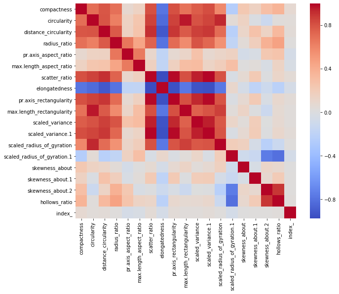

```python
plt.figure(figsize = (10,8))
sns.heatmap(corr_mat, cmap = "coolwarm")
```

#### The correlation analysis reveals that there are indeed several columns that have strong correlations with each other. PCA would be the right approach to reduce processing times on a dataset like this.

```python
corr_mat[corr_mat > 0.8]
```

|  | compactness | circularity | distance_circularity | radius_ratio | pr.axis_aspect_ratio | max.length_aspect_ratio | scatter_ratio | elongatedness | pr.axis_rectangularity | max.length_rectangularity | scaled_variance | scaled_variance.1 | scaled_radius_of_gyration | scaled_radius_of_gyration.1 | skewness_about | skewness_about.1 | skewness_about.2 | hollows_ratio | index_ |
| --- | --- | --- | --- | --- | --- | --- | --- | --- | --- | --- | --- | --- | --- | --- | --- | --- | --- | --- | --- |
| compactness | 1.000000 | NaN | NaN | NaN | NaN | NaN | 0.812668 | NaN | 0.812611 | NaN | NaN | 0.819067 | NaN | NaN | NaN | NaN | NaN | NaN | NaN |
| circularity | NaN | 1.000000 | NaN | NaN | NaN | NaN | 0.858999 | NaN | 0.856520 | 0.965827 | 0.806643 | 0.851370 | 0.935201 | NaN | NaN | NaN | NaN | NaN | NaN |
| distance_circularity | NaN | NaN | 1.000000 | NaN | NaN | NaN | 0.907703 | NaN | 0.895704 | NaN | 0.864475 | 0.890115 | NaN | NaN | NaN | NaN | NaN | NaN | NaN |
| radius_ratio | NaN | NaN | NaN | 1.0 | NaN | NaN | NaN | NaN | NaN | NaN | NaN | NaN | NaN | NaN | NaN | NaN | NaN | NaN | NaN |
| pr.axis_aspect_ratio | NaN | NaN | NaN | NaN | 1.0 | NaN | NaN | NaN | NaN | NaN | NaN | NaN | NaN | NaN | NaN | NaN | NaN | NaN | NaN |
| max.length_aspect_ratio | NaN | NaN | NaN | NaN | NaN | 1.0 | NaN | NaN | NaN | NaN | NaN | NaN | NaN | NaN | NaN | NaN | NaN | NaN | NaN |
| scatter_ratio | 0.812668 | 0.858999 | 0.907703 | NaN | NaN | NaN | 1.000000 | NaN | 0.992120 | 0.809880 | 0.951617 | 0.996048 | 0.800575 | NaN | NaN | NaN | NaN | NaN | NaN |
| elongatedness | NaN | NaN | NaN | NaN | NaN | NaN | NaN | 1.0 | NaN | NaN | NaN | NaN | NaN | NaN | NaN | NaN | NaN | NaN | NaN |
| pr.axis_rectangularity | 0.812611 | 0.856520 | 0.895704 | NaN | NaN | NaN | 0.992120 | NaN | 1.000000 | 0.812767 | 0.938153 | 0.991919 | NaN | NaN | NaN | NaN | NaN | NaN | NaN |
| max.length_rectangularity | NaN | 0.965827 | NaN | NaN | NaN | NaN | 0.809880 | NaN | 0.812767 | 1.000000 | NaN | NaN | 0.865800 | NaN | NaN | NaN | NaN | NaN | NaN |
| scaled_variance | NaN | 0.806643 | 0.864475 | NaN | NaN | NaN | 0.951617 | NaN | 0.938153 | NaN | 1.000000 | 0.949359 | NaN | NaN | NaN | NaN | NaN | NaN | NaN |
| scaled_variance.1 | 0.819067 | 0.851370 | 0.890115 | NaN | NaN | NaN | 0.996048 | NaN | 0.991919 | NaN | 0.949359 | 1.000000 | NaN | NaN | NaN | NaN | NaN | NaN | NaN |
| scaled_radius_of_gyration | NaN | 0.935201 | NaN | NaN | NaN | NaN | 0.800575 | NaN | NaN | 0.865800 | NaN | NaN | 1.000000 | NaN | NaN | NaN | NaN | NaN | NaN |
| scaled_radius_of_gyration.1 | NaN | NaN | NaN | NaN | NaN | NaN | NaN | NaN | NaN | NaN | NaN | NaN | NaN | 1.0 | NaN | NaN | NaN | NaN | NaN |
| skewness_about | NaN | NaN | NaN | NaN | NaN | NaN | NaN | NaN | NaN | NaN | NaN | NaN | NaN | NaN | 1.0 | NaN | NaN | NaN | NaN |
| skewness_about.1 | NaN | NaN | NaN | NaN | NaN | NaN | NaN | NaN | NaN | NaN | NaN | NaN | NaN | NaN | NaN | 1.0 | NaN | NaN | NaN |
| skewness_about.2 | NaN | NaN | NaN | NaN | NaN | NaN | NaN | NaN | NaN | NaN | NaN | NaN | NaN | NaN | NaN | NaN | 1.000000 | 0.894029 | NaN |
| hollows_ratio | NaN | NaN | NaN | NaN | NaN | NaN | NaN | NaN | NaN | NaN | NaN | NaN | NaN | NaN | NaN | NaN | 0.894029 | 1.000000 | NaN |
| index_ | NaN | NaN | NaN | NaN | NaN | NaN | NaN | NaN | NaN | NaN | NaN | NaN | NaN | NaN | NaN | NaN | NaN | NaN | 1.0 |

#### Here are some possible columns that could be dropped

[output not shown]

#### We can now take a detailed look at these columns through pairplot

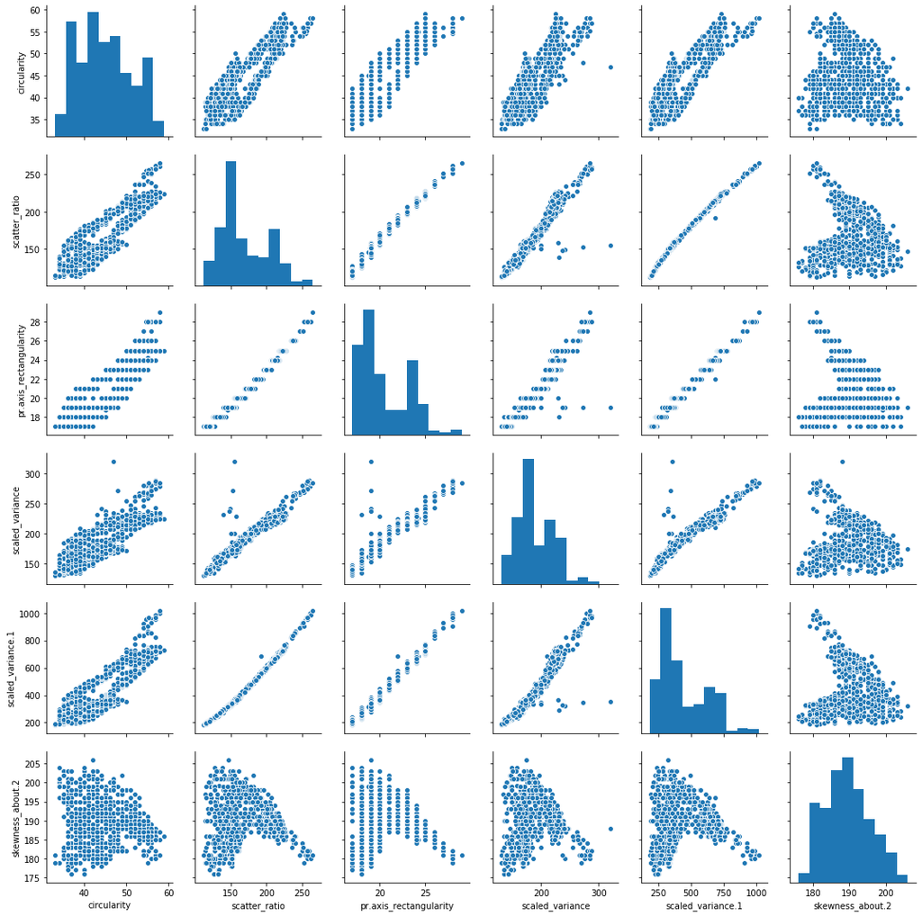

```python
plt.figure(figsize = (20,20))
sns.pairplot(veh_df_upd[["circularity","scatter_ratio","pr.axis_rectangularity","scaled_variance","scaled_variance.1","skewness_about.2"]])
```

#### Based on this diagram, we can easily remove

```
1. scatter_ratio
2. scaled_variance
3. pr.axis_rectangularity
```

### We can graph the individual elements out and see if they have a correlation with the outcomes

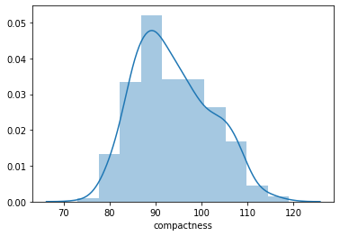

```python
sns.distplot(veh_df_upd["compactness"],bins = 10)
```

#### Distribution of compactness has a slight right skew, but other than that it looks acceptable

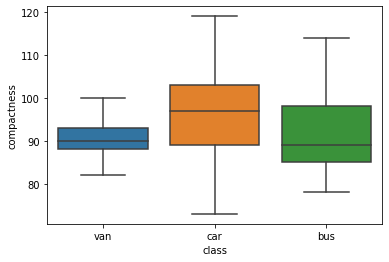

```python
sns.boxplot(y = "compactness", x= "class", data = veh_df_upd)
```

#### Cars have a higher compactness than the other classes. This makes sense as cars are by nature smaller capacity

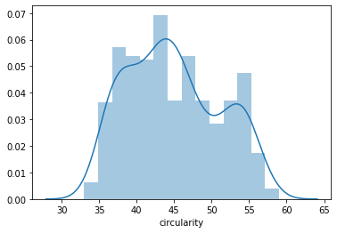

```python
sns.distplot(veh_df_upd["circularity"])
```

#### Circularity too has a marginal right skew, however, it does not demonstrate significant outliers

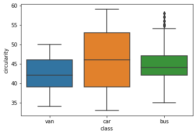

```python
sns.boxplot(y = "circularity", x= "class", data = veh_df_upd)
```

#### Cars have a higher median circularity than buses and vans

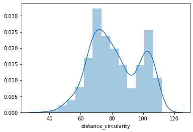

```python
sns.distplot(veh_df_upd["distance_circularity"])
```

#### Distance Circularity distribution looks acceptable. However, the data seems to have a lesser quantity in the 85-95 region

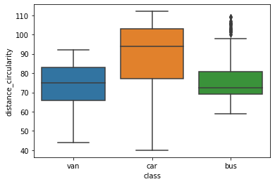

```python
sns.boxplot(y = "distance_circularity", x= "class", data = veh_df_upd)
```

#### Same as circularity, this too is higher for cars. The difference hower is that the median distance circularity for buses is lower than vans

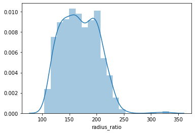

```python
sns.distplot(veh_df_upd["radius_ratio"])
```

#### This distribution needs further examination. The tail is quite long on the right and we may need to see what number of outliers are acceptable

```python
radius_ratio = stat.zscore (veh_df_upd["radius_ratio"])
radius_ratio[(radius_ratio > 3) | (radius_ratio < -3)]
```

```
array([4.09585335, 4.57439007, 4.90338406])
```

#### There are three outliers which stick out. We would like to drop them in later data processing or predict them

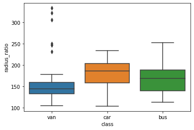

```python
sns.boxplot(y = "radius_ratio", x= "class", data = veh_df_upd)
```

#### Cars seem to have a larger median radius ratio than buses, which have a larger radius ratio than vans.

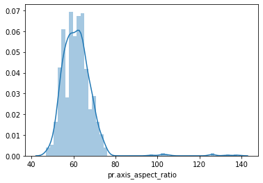

```python
sns.distplot(veh_df_upd["pr.axis_aspect_ratio"])
```

#### This distribution needs further examination. The tail is quite long on the right and we may need to see what number of outliers are acceptable

```python
axis_ratio = stat.zscore (veh_df_upd["pr.axis_aspect_ratio"])
axis_ratio[(axis_ratio > 3) | (axis_ratio < -3)]
```

```
array([5.2242852 , 8.13335382, 8.13335382, 9.01872253, 5.09780395,
       9.65112875, 4.46539773, 5.47724768])
```

#### There are eight outliers which stick out. We would like to drop them in later data processing or predict them. In this case, we will select 5.5 as the critical value as half of the outliers are inside that range. The next block of outliers starts at 8. This bit of preprocessing will be performed after the data analysis

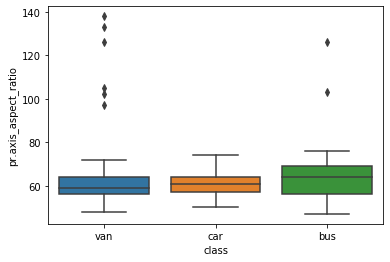

```python
sns.boxplot(y = "pr.axis_aspect_ratio", x= "class", data = veh_df_upd)
```

#### Buses seem to have a greater pr.axis_aspect_ratio than cars which are mildly larger than vans (medians)

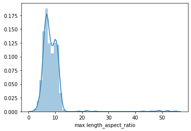

```python
sns.distplot(veh_df_upd["max.length_aspect_ratio"])
```

#### This distribution needs further examination. The tail is quite long on the right and we may need to see what number of outliers are acceptable

```python
len_aspect_ratio = stat.zscore (veh_df_upd["max.length_aspect_ratio"])
len_aspect_ratio[(len_aspect_ratio > 3) | (len_aspect_ratio < -3)]
```

```
array([ 9.40892933,  8.75890668,  9.40892933,  8.54223247,  7.45886139,
        8.75890668,  3.5587255 ,  8.10888404, 10.05895198])
```

#### There are 8 outliers outside z = 4. We would like to drop them in later data processing or predict them

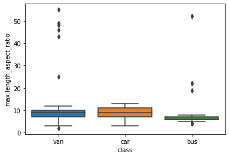

```python
sns.boxplot(y = "max.length_aspect_ratio", x= "class", data = veh_df_upd)
```

#### Cars have a higher median length aspect ratio than vans and buses

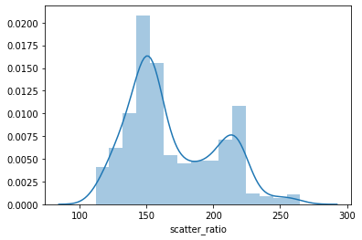

```python
sns.distplot(veh_df_upd["scatter_ratio"])
```

#### The distribution for scatter ratio seems correct and without many outliers

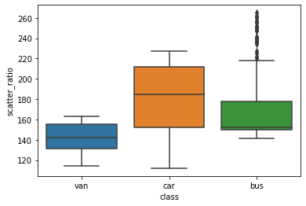

```python
sns.boxplot(y = "scatter_ratio", x= "class", data = veh_df_upd)
```

#### The median car scatter ratio is much larger than the median van/bus scatter ratio. However, buses have large outliers

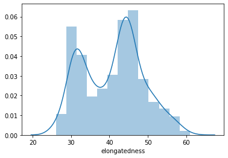

```python
sns.distplot(veh_df_upd["elongatedness"])
```

#### The elongatedness seems to have an acceptable distribution

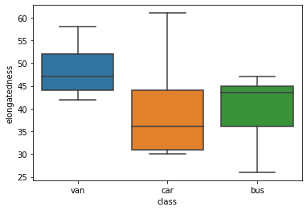

```python
sns.boxplot(y = "elongatedness", x= "class", data = veh_df_upd)
```

#### Vans (median) are more elongated than buses, which are on median more elongated than cars

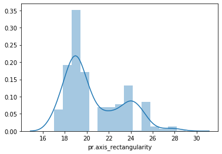

```python
sns.distplot(veh_df_upd["pr.axis_rectangularity"])
```

#### Despite having a long right tail, the distribution seems acceptable as the tail is not completely flat. There are several occurences towards the right

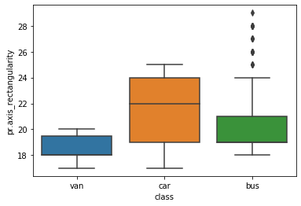

```python
sns.boxplot(y = "pr.axis_rectangularity", x= "class", data = veh_df_upd)
```

#### The median axis rectangularity for cars is greater than vans and buses

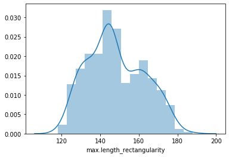

```python
sns.distplot(veh_df_upd["max.length_rectangularity"])
```

#### The max length rectangularity distribution looks almost normal

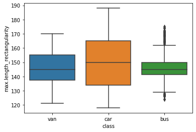

```python
sns.boxplot(y = "max.length_rectangularity", x= "class", data = veh_df_upd)
```

#### cars have greater max length rectangularity (median) than buses and vans

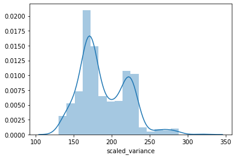

```python
sns.distplot(veh_df_upd["scaled_variance"])
```

#### The scaled variance column seems to have a long right sided tail. It makes sense to examine it further

```python
scaled_variance = stat.zscore (veh_df_upd["scaled_variance"])
scaled_variance[(scaled_variance > 3) | (scaled_variance < -3)]
```

```
array([3.16164465, 4.18039517, 3.06613679, 3.06613679, 3.12980869,
       3.06613679])
```

#### The only major outlier is the one outside z =4

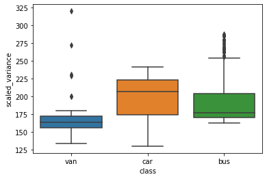

```python
sns.boxplot(y = "scaled_variance", x= "class", data = veh_df_upd)
```

#### The median scaled variance for cars is more than buses which is in turn more than vans

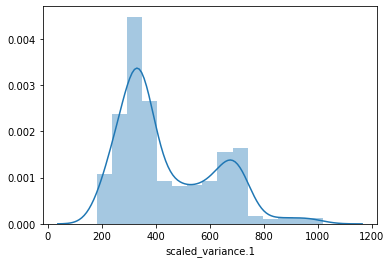

```python
sns.distplot(veh_df_upd["scaled_variance.1"])
```

#### Scaled variance seems close to normal, although it has a right tail

```python
scaled_variance_1 = stat.zscore (veh_df_upd["scaled_variance.1"])
scaled_variance_1[(scaled_variance_1 > 3) | (scaled_variance_1 < -3)]
```

```
array([3.15174525, 3.06130541, 3.08956786, 3.26479506])
```

#### Since most of the outliers are quite close to each other, we will continue as is

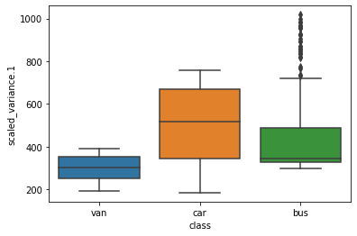

```python
sns.boxplot(y = "scaled_variance.1", x= "class", data = veh_df_upd)
```

#### The median scaled variance 1 is also highest for cars, then buses and the lowest for vans

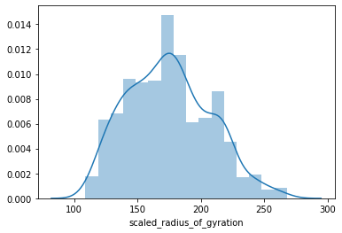

```python
sns.distplot(veh_df_upd["scaled_radius_of_gyration"])
```

#### The distribution appears to be mostly normal, with a right sided tail

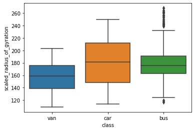

```python
sns.boxplot(y = "scaled_radius_of_gyration", x= "class", data = veh_df_upd)
```

#### The scaled radius of gyration is again higher for cars than buses and lowest for vans

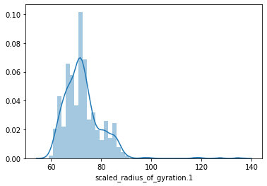

```python
sns.distplot(veh_df_upd["scaled_radius_of_gyration.1"])
```

#### The scaled_radius_of_gyration.1 column seems to have a long right sided tail. It makes sense to examine it further

```python
scaled_radius_of_gyration_1 = stat.zscore (veh_df_upd["scaled_radius_of_gyration.1"])
scaled_radius_of_gyration_1[(scaled_radius_of_gyration_1 > 3) | (scaled_radius_of_gyration_1 < -3)]
```

```
array([7.29249368, 6.08925181, 6.22294535, 3.28168745, 8.36204201,
       3.54907453])
```

#### We have outliers above z = 4. we will have to treat them

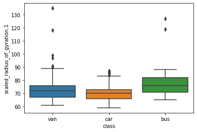

```python
sns.boxplot(y = "scaled_radius_of_gyration.1", x= "class", data = veh_df_upd)
```

#### buses have the highest median scaled radius of gyration while cars have the lowest

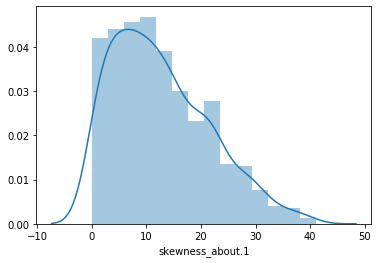

```python
sns.distplot(veh_df_upd["skewness_about.1"])
```

#### This is a right sided distribution that seems acceptable. The outliers have a non neglible frequency

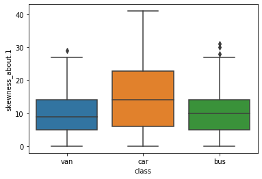

```python
sns.boxplot(y = "skewness_about.1", x= "class", data = veh_df_upd)
```

#### The median Skewness about 1 for cars is the greatest and lowest for vans.

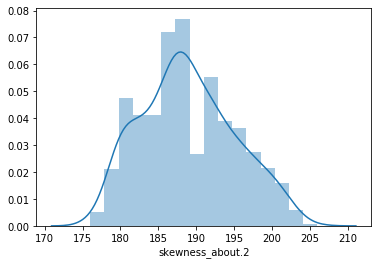

```python
sns.distplot(veh_df_upd["skewness_about.2"])
```

#### This is almost a completely normal distribution with a very mild right sided tail

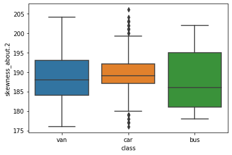

```python
sns.boxplot(y = "skewness_about.2", x= "class", data = veh_df_upd)
```

#### The skewness about 2 is largest for cars (although marginally) and lowest for buses

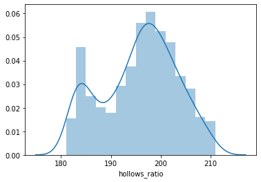

```python
sns.distplot(veh_df_upd["hollows_ratio"])
```

#### This distribution too looks devoid of outliers and we can proceed with it

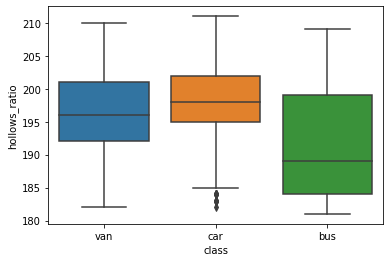

```python
sns.boxplot(y = "hollows_ratio", x= "class", data = veh_df_upd)
```

#### The median hollows ratio is largest for cars and lowest for buses

### Lets replace the target class by numbers

```python
veh_df_upd = veh_df_upd.replace({"class":{"car":1,"van":2,"bus":3}})
```

### Now we can run predictions on the outlier elements highlighted by our analysis

#### Replacing outliers for radius_ratio

```python
##grab the dataset
veh_df_rad = veh_df_upd[(stat.zscore(veh_df_upd["radius_ratio"]) < 3) & (stat.zscore(veh_df_upd["radius_ratio"]) > -3)]
x = veh_df_rad.drop(["radius_ratio", "class", "index_"], axis = 1)
y = veh_df_rad["radius_ratio"]
x_train, x_test, y_train, y_test = train_test_split(x, y, test_size = 0.2, random_state = 100)

#creating a linear regression
lin_reg = LinearRegression()
lin_reg.fit(x_train, y_train)
print(lin_reg.score(x_train, y_train))
print(lin_reg.score(x_test, y_test))

##The set that needs to be predicted
impute_x = veh_df_upd[(stat.zscore(veh_df_upd["radius_ratio"]) > 3) | (stat.zscore(veh_df_upd["radius_ratio"]) < -3)]
indice_x = np.array(impute_x["index_"])
impute_x = impute_x.drop(["radius_ratio", "class", "index_"], axis = 1)
pred = lin_reg.predict(impute_x)
print(pred)
i = 0
print (np.sort(veh_df_upd["radius_ratio"])[836:])

##Updating it back
for prediction in pred:
    indice = indice_x[i]
    veh_df.at[indice, "radius_ratio"] = prediction
    i = i + 1
```

```
0.972224981350253
0.9657706508197696
[293.21776944 320.02696885 320.53289906]
[306. 322. 333.]
```

#### Replacing outliers for pr.axis_aspect_ratio

```python
##Grab the dataset
veh_df_axis = veh_df_upd[(stat.zscore(veh_df_upd["pr.axis_aspect_ratio"]) < 5.5)]
x = veh_df_axis.drop(["pr.axis_aspect_ratio", "class", "index_"], axis = 1)
y = veh_df_axis["pr.axis_aspect_ratio"]
x_train, x_test, y_train, y_test = train_test_split(x, y, test_size = 0.2, random_state = 100)

#creating a linear regression
lin_reg = LinearRegression()
lin_reg.fit(x_train, y_train)
print(lin_reg.score(x_train, y_train))
print(lin_reg.score(x_test, y_test))

##The set that needs to be predicted
impute_x = veh_df_upd[(stat.zscore(veh_df_upd["pr.axis_aspect_ratio"]) > 5.5)]
indice_x = np.array(impute_x["index_"])
impute_x = impute_x.drop(["pr.axis_aspect_ratio", "class", "index_"], axis = 1)
pred = lin_reg.predict(impute_x)
print(pred)
i = 0
print (np.sort(veh_df_upd["pr.axis_aspect_ratio"])[835:])

##Updating it back
for prediction in pred:
    indice = indice_x[i]
    veh_df.at[indice, "pr.axis_aspect_ratio"] = prediction
    i = i + 1
```

```
0.9101412606589514
0.860635497858881
[127.69274    114.78311196 126.66290622 139.23057459]
[126. 126. 133. 138.]
```

#### Replacing outliers for max.length_aspect_ratio

```python
##Grab the dataset
veh_df_axis = veh_df_upd[(stat.zscore(veh_df_upd["max.length_aspect_ratio"]) <= 4)]
x = veh_df_axis.drop(["max.length_aspect_ratio", "class", "index_"], axis = 1)
y = veh_df_axis["max.length_aspect_ratio"]
x_train, x_test, y_train, y_test = train_test_split(x, y, test_size = 0.25, random_state = 100)

#creating a linear regression
lin_reg = LinearRegression()
lin_reg.fit(x_train, y_train)
print(lin_reg.score(x_train, y_train))
print(lin_reg.score(x_test, y_test))

##The set that needs to be predicted
impute_x = veh_df_upd[(stat.zscore(veh_df_upd["max.length_aspect_ratio"]) > 4)]
indice_x = np.array(impute_x["index_"])
impute_x = impute_x.drop(["max.length_aspect_ratio", "class", "index_"], axis = 1)
pred = lin_reg.predict(impute_x)
print(pred)
i = 0
print (np.sort(veh_df_upd["max.length_aspect_ratio"])[831:])

##Updating it back
for prediction in pred:
    indice = indice_x[i]
    veh_df.at[indice, "max.length_aspect_ratio"] = prediction
    i = i + 1
```

```
0.631740569073979
0.8284664045812096
[ 5.16359743  9.15155074  6.21204751 11.97839546 11.02704192  9.04972557
 10.02060301  8.11324793]
[43 46 48 49 49 52 52 55]
```

#### Replacing outliers for scaled_variance

```python
##Grab the dataset
veh_df_axis = veh_df_upd[(stat.zscore(veh_df_upd["scaled_variance"]) <= 4)]
x = veh_df_axis.drop(["scaled_variance", "class", "index_"], axis = 1)
y = veh_df_axis["scaled_variance"]
x_train, x_test, y_train, y_test = train_test_split(x, y, test_size = 0.25, random_state = 100)

#creating a linear regression
lin_reg = LinearRegression()
lin_reg.fit(x_train, y_train)
print(lin_reg.score(x_train, y_train))
print(lin_reg.score(x_test, y_test))

##The set that needs to be predicted
impute_x = veh_df_upd[(stat.zscore(veh_df_upd["scaled_variance"]) > 4)]
indice_x = np.array(impute_x["index_"])
impute_x = impute_x.drop(["scaled_variance", "class", "index_"], axis = 1)
pred = lin_reg.predict(impute_x)
print(pred)
i = 0
print (np.sort(veh_df_upd["scaled_variance"])[838:])

##Updating it back
for prediction in pred:
    indice = indice_x[i]
    veh_df.at[indice, "scaled_variance"] = prediction
    i = i + 1
```

```
0.979941230816113
0.9804741059398676
[257.34644031]
[320.]
```

#### Replacing outliers for scaled_radius_of_gyration.1

```python
##Grab the dataset
veh_df_axis = veh_df_upd[(stat.zscore(veh_df_upd["scaled_radius_of_gyration.1"]) <= 4)]
x = veh_df_axis.drop(["scaled_radius_of_gyration.1", "class", "index_"], axis = 1)
y = veh_df_axis["scaled_radius_of_gyration.1"]
x_train, x_test, y_train, y_test = train_test_split(x, y, test_size = 0.25, random_state = 100)

#creating a linear regression
lin_reg = LinearRegression()
lin_reg.fit(x_train, y_train)
print(lin_reg.score(x_train, y_train))
print(lin_reg.score(x_test, y_test))

##The set that needs to be predicted
impute_x = veh_df_upd[(stat.zscore(veh_df_upd["scaled_radius_of_gyration.1"]) > 4)]
indice_x = np.array(impute_x["index_"])
impute_x = impute_x.drop(["scaled_radius_of_gyration.1", "class", "index_"], axis = 1)
pred = lin_reg.predict(impute_x)
print(pred)
i = 0
print (np.sort(veh_df_upd["scaled_radius_of_gyration.1"])[835:])

##Updating it back
for prediction in pred:
    indice = indice_x[i]
    veh_df.at[indice, "scaled_radius_of_gyration.1"] = prediction
    i = i + 1
```

```
0.9156783833084287
0.8820798833692842
[109.80154408  99.95911972 111.09827305 106.3424406 ]
[118. 119. 127. 135.]
```

### Updating the dataframe

#### We take the values from the data frame we updated

```python
veh_df_upd = veh_df[(veh_df["compactness"].isnull() == False) &
                      (veh_df["circularity"].isnull() == False) &
                      (veh_df["distance_circularity"].isnull() == False) &
                      (veh_df["radius_ratio"].isnull() == False) &
                      (veh_df["pr.axis_aspect_ratio"].isnull() == False) &
                      (veh_df["max.length_aspect_ratio"].isnull() == False) &
                      (veh_df["scatter_ratio"].isnull() == False) &
                      (veh_df["elongatedness"].isnull() == False) &
                      (veh_df["pr.axis_rectangularity"].isnull() == False) &
                      (veh_df["max.length_rectangularity"].isnull() == False) &
                      (veh_df["scaled_variance"].isnull() == False) &
                      (veh_df["scaled_variance.1"].isnull() == False) &
                      (veh_df["scaled_radius_of_gyration"].isnull() == False) &
                      (veh_df["scaled_radius_of_gyration.1"].isnull() == False) &
                      (veh_df["skewness_about"].isnull() == False) &
                      (veh_df["skewness_about.1"].isnull() == False) &
                      (veh_df["skewness_about.2"].isnull() == False) &
                      (veh_df["hollows_ratio"].isnull() == False)]
```

### Dropping the index_ variable from the data frame as we only needed it to update the outliers and missing values

```python
veh_df_upd = veh_df_upd.drop("index_", axis = 1)
```

#### Making sure target class doesnt have any issues

```python
veh_df_upd["class"].nunique()
```

```
3
```

#### Scale the data down using min max scaler

```python
min_max = MinMaxScaler()
```

```python
to_transform = veh_df_upd.drop("class", axis = 1)
transformed_ = min_max.fit_transform(to_transform)
transformed_df = pd.DataFrame(transformed_, columns = to_transform.columns)
class_df = pd.DataFrame(np.array(veh_df_upd["class"]), columns = ["class"])
veh_df_upd = pd.concat([transformed_df,class_df], axis = 1)
veh_df_upd.head()
```

|  | compactness | circularity | distance_circularity | radius_ratio | pr.axis_aspect_ratio | max.length_aspect_ratio | scatter_ratio | elongatedness | pr.axis_rectangularity | max.length_rectangularity | scaled_variance | scaled_variance.1 | scaled_radius_of_gyration | scaled_radius_of_gyration.1 | skewness_about | skewness_about.1 | skewness_about.2 | hollows_ratio | class |
| --- | --- | --- | --- | --- | --- | --- | --- | --- | --- | --- | --- | --- | --- | --- | --- | --- | --- | --- | --- |
| 0 | 0.478261 | 0.576923 | 0.597222 | 0.341749 | 0.271060 | 0.347826 | 0.326797 | 0.457143 | 0.250000 | 0.585714 | 0.291139 | 0.233813 | 0.471698 | 0.211139 | 0.272727 | 0.390244 | 0.366667 | 0.533333 | van |
| 1 | 0.391304 | 0.307692 | 0.611111 | 0.170875 | 0.108424 | 0.304348 | 0.241830 | 0.542857 | 0.166667 | 0.357143 | 0.253165 | 0.175060 | 0.308176 | 0.249528 | 0.409091 | 0.341463 | 0.433333 | 0.600000 | van |
| 2 | 0.673913 | 0.653846 | 0.916667 | 0.484915 | 0.206005 | 0.347826 | 0.620915 | 0.171429 | 0.500000 | 0.571429 | 0.588608 | 0.540767 | 0.698113 | 0.268723 | 0.636364 | 0.219512 | 0.400000 | 0.500000 | car |
| 3 | 0.434783 | 0.307692 | 0.583333 | 0.254003 | 0.173478 | 0.304348 | 0.209150 | 0.571429 | 0.166667 | 0.357143 | 0.189873 | 0.149880 | 0.113208 | 0.076778 | 0.272727 | 0.243902 | 0.766667 | 0.866667 | van |
| 4 | 0.260870 | 0.423077 | 0.416667 | 0.466442 | 0.607174 | 0.137548 | 0.241830 | 0.542857 | 0.166667 | 0.371429 | 0.702532 | 0.169065 | 0.496855 | 0.975110 | 0.409091 | 0.268293 | 0.133333 | 0.066667 | bus |

#### Let us also create a data set which reduces the highly correlated columns pointed out previously in the pairplot observations. We can check if this provides us better results

```python
veh_df_upd_reduced = veh_df_upd.drop(["scatter_ratio", "scaled_variance", "pr.axis_rectangularity"] , axis = 1)
```

## Q3 Split the data into train and test (Suggestion: specify “random state” if you are using train_test_split from Sklearn)

## Ans3

#### Partition the data into target and independent variables

```python
y = veh_df_upd["class"]
x = veh_df_upd.drop(["class"], axis = 1)
```

#### Split the data into train and test

```python
x_train, x_test, y_train, y_test = train_test_split(x, y, test_size = 0.25, random_state = 100)
```

## Q4 Train a Support vector machine using the train set and get the accuracy on the test set

## Ans4

### Deploy an SVC to run prediction on the raw data

#### create a parameter grid to optimize SVC

```python
param_grid = {"C": [90, 95, 100, 105, 110],
              "gamma": [0.3,0.4,0.5,0.6,0.7,0.8,0.9,1,1.1,1.2,1.3,1.4,1.5,1.6,1.7],
              "decision_function_shape":['ovr'],
              "class_weight":["balanced"],
              "break_ties" : [True]}
```

#### We start with the reduced dataset first (dropped columns). Refreshing the data from the dataset with the reduced columns and running SVC on it with KFold validation. Then we can pinpoint the range of accuracy

```python
y = veh_df_upd_reduced["class"]
x = veh_df_upd_reduced.drop(["class"], axis = 1)
x_train, x_test, y_train, y_test = train_test_split(x, y, test_size = 0.25, random_state = 100)
svc_ = GridSearchCV(SVC(class_weight = "balanced"), param_grid = param_grid, cv = 3, verbose=True)
svc_.fit(x_train, y_train)
y_pred = svc_.predict(x_test)
print("Best parameters", svc_.best_params_)
print(classification_report(y_test, y_pred))
print("Accuracy is:" , round(svc_.score(x_test,y_test) * 100,2))
```

```
Fitting 3 folds for each of 75 candidates, totalling 225 fits
```

```
[Parallel(n_jobs=1)]: Using backend SequentialBackend with 1 concurrent workers.
```

```
Best parameters {'C': 90, 'break_ties': True, 'class_weight': 'balanced', 'decision_function_shape': 'ovr', 'gamma': 1}
              precision    recall  f1-score   support

         bus       1.00      0.98      0.99        52
         car       1.00      1.00      1.00       100
         van       0.98      1.00      0.99        58

    accuracy                           1.00       210
   macro avg       0.99      0.99      0.99       210
weighted avg       1.00      1.00      1.00       210

Accuracy is: 99.52
```

```
[Parallel(n_jobs=1)]: Done 225 out of 225 | elapsed:    2.0s finished
```

```
Range of Results [ 95.24  96.43  96.43  97.62  97.62  98.81  98.81  98.81 100.   100.  ]
Results Accuracy: 97.98 %
Results Std: 1.51 %
95% confidence range 94.96 - 100
```

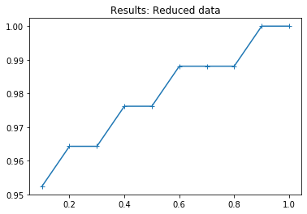

```python
num_fold = 10
kfold = KFold(n_splits=num_fold, shuffle = True, random_state = 100)

svc_kfold = SVC(C = 90, class_weight = "balanced", gamma = 1, decision_function_shape = "ovr", break_ties = True, kernel = "rbf")
kfold_result_reduced = cross_val_score(svc_kfold, x, y, cv = kfold)
kfold_result_reduced = np.sort(kfold_result_reduced)
print("Range of Results", np.round(kfold_result_reduced*100,2))
perc_accuracy = kfold_result_reduced.mean()*100
std_dev = kfold_result_reduced.std()*100
print ("Results Accuracy:", round(perc_accuracy,2),"%")
print ("Results Std:", round(std_dev,2), "%")
min_range = round((perc_accuracy - 2*std_dev),2)
max_range = round((perc_accuracy + 2*std_dev),2)
if min_range < 0:
    min_range = 0
if max_range > 100:
    max_range = 100
print ("95% confidence range", min_range, "-", max_range)
plt.plot((np.array(range(1, 11))/10),kfold_result_reduced, marker = "+")
plt.title("Results: Reduced data")
```

#### The accuracy range with 95% confidence is 94.96% - 100%. The accuracy score was 97.97%

#### Now we can try with the full dataset

```python
y = veh_df_upd["class"]
x = veh_df_upd.drop(["class"], axis = 1)
x_train, x_test, y_train, y_test = train_test_split(x, y, test_size = 0.25, random_state = 100)
svc_ = GridSearchCV(SVC(class_weight = "balanced"), param_grid = param_grid, cv = 3, verbose=True)
svc_.fit(x_train, y_train)
y_pred = svc_.predict(x_test)
print("Best parameters", svc_.best_params_)
print(classification_report(y_test, y_pred))
print("Accuracy is:" , round(svc_.score(x_test,y_test) * 100,2))
```

```
Fitting 3 folds for each of 75 candidates, totalling 225 fits
```

```
[Parallel(n_jobs=1)]: Using backend SequentialBackend with 1 concurrent workers.
```

```
Best parameters {'C': 95, 'break_ties': True, 'class_weight': 'balanced', 'decision_function_shape': 'ovr', 'gamma': 0.8}
              precision    recall  f1-score   support

         bus       1.00      0.98      0.99        52
         car       1.00      0.99      0.99       100
         van       0.97      1.00      0.98        58

    accuracy                           0.99       210
   macro avg       0.99      0.99      0.99       210
weighted avg       0.99      0.99      0.99       210

Accuracy is: 99.05
```

```
[Parallel(n_jobs=1)]: Done 225 out of 225 | elapsed:    2.5s finished
```

#### Running the SVC on the raw data provides us 99% accuracy. This is just lower than the dataset where we reduced columns with duplicate information. We can surmise that reducing duplicated columns does not degrade results tangibly

## Q5 Perform K-fold cross validation and get the cross validation score of the model

## Ans5

#### We now run a K fold cross validation and determine performance range for the full dataset

```
Range of Results [ 96.43  97.62  97.62  97.62  98.81  98.81  98.81  98.81  98.81 100.  ]
Results Accuracy: 98.33 %
Results Std: 0.95 %
95% confidence range 96.43 - 100
```

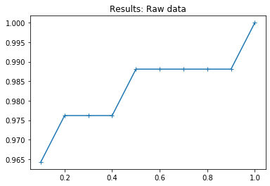

```python
num_fold = 10
kfold = KFold(n_splits=num_fold, shuffle = True, random_state = 100)

svc_kfold = SVC(C = 95, class_weight = "balanced", gamma = 0.8, kernel = "rbf", decision_function_shape= "ovr", break_ties=True)
kfold_result = cross_val_score(svc_kfold, x, y, cv = kfold)
kfold_result = np.sort(kfold_result)
print("Range of Results", np.round(kfold_result*100,2))
perc_accuracy = kfold_result.mean()*100
std_dev = kfold_result.std()*100
print ("Results Accuracy:", round(perc_accuracy,2),"%")
print ("Results Std:", round(std_dev,2), "%")
min_range = round((perc_accuracy - 2*std_dev),2)
max_range = round((perc_accuracy + 2*std_dev),2)
if min_range < 0:
    min_range = 0
if max_range > 100:
    max_range = 100
print ("95% confidence range", min_range, "-", max_range)
plt.plot((np.array(range(1, 11))/10),kfold_result, marker = "+")
plt.title("Results: Raw data")
```

#### The performance range for this SVC is 96.43% - 100%, this range is just higher than the range for the model with reduced duplicates

## Q6 Use PCA from Scikit learn, extract Principal Components that capture about 95% of the variance in the data

## Ans6

### Converting raw data into PCAs

#### We first add all 18 components of the full dataset to see how much variance can be explained

```python
pca = PCA(n_components=18)
```

```python
pca.fit(x)
```

```
PCA(copy=True, iterated_power='auto', n_components=18, random_state=None,
    svd_solver='auto', tol=0.0, whiten=False)
```

```python
print("Variance explained by individual components", np.round(pca.explained_variance_ratio_ * 100,2))
```

```
Variance explained by individual components [5.798e+01 1.788e+01 7.990e+00 6.250e+00 3.190e+00 2.130e+00 1.390e+00
 1.090e+00 5.600e-01 3.900e-01 3.600e-01 3.000e-01 2.100e-01 1.100e-01
 9.000e-02 4.000e-02 4.000e-02 0.000e+00]
```

#### Since the values here dont look very legible, lets create an elbow plot

```python
i = 0
for el in  pca.explained_variance_ratio_:
    if i > 0:
        el = el + pca.explained_variance_ratio_[i-1]
        pca.explained_variance_ratio_[i] = el
    i = i + 1
```

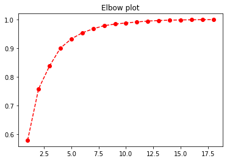

```python
plt.title("Elbow plot")
plt.plot(list(range(1,19)),pca.explained_variance_ratio_, "r--", marker = "o")
```

#### Based on this plot, we see that around the 6th axis we can explain above 95% of the variance

#### Now we reduce the PCA components to 6 and try an SVC model

```python
pca = PCA(n_components=6)
pca.fit(x)
xpca = pca.transform(x)
print("Variance explained by 6 PCA components", round(np.sum(pca.explained_variance_ratio_)*100,2))
```

```
Variance explained by 6 PCA components 95.42
```

```
Variance explained by individual components [57.98 17.88  7.99  6.25  3.19  2.13]
```

```
<BarContainer object of 6 artists>
```

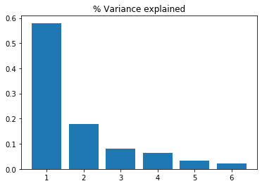

```python
x_train, x_test, y_train, y_test = train_test_split(xpca, y, test_size = 0.25, random_state = 100)
print("Variance explained by individual components", np.round(pca.explained_variance_ratio_*100,2))
plt.title("% Variance explained")
plt.bar(list(range(1,7)), pca.explained_variance_ratio_)
```

#### Now we run SVC to predict based on 6 components

```python
svc_ = GridSearchCV(SVC(class_weight = "balanced"), param_grid = param_grid, cv = 3, verbose=True)
svc_.fit(x_train, y_train)
y_pred = svc_.predict(x_test)
print("Best parameters", svc_.best_params_)
print(classification_report(y_test, y_pred))
print("Accuracy is:" , round(svc_.score(x_test,y_test) * 100,2))
```

```
Fitting 3 folds for each of 75 candidates, totalling 225 fits
```

```
[Parallel(n_jobs=1)]: Using backend SequentialBackend with 1 concurrent workers.
```

```
Best parameters {'C': 95, 'break_ties': True, 'class_weight': 'balanced', 'decision_function_shape': 'ovr', 'gamma': 0.3}
              precision    recall  f1-score   support

         bus       0.86      0.92      0.89        52
         car       0.99      0.80      0.88       100
         van       0.78      0.98      0.87        58

    accuracy                           0.88       210
   macro avg       0.88      0.90      0.88       210
weighted avg       0.90      0.88      0.88       210

Accuracy is: 88.1
```

```
[Parallel(n_jobs=1)]: Done 225 out of 225 | elapsed:    1.8s finished
```

#### The accuracy drop seems quite large when running the model with only 6 components. Let us do a KFold analysis to find out what the range is

```
Range of Results [85.71 86.9  88.1  88.1  88.1  90.48 90.48 92.77 94.05 94.05]
Results Accuracy: 89.87 %
Results Std: 2.82 %
95% confidence range 84.23 - 95.51
```

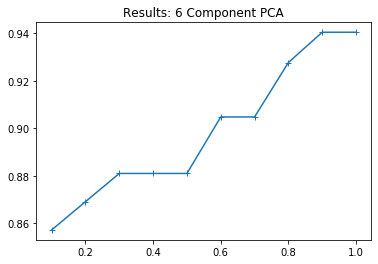

```python
num_fold = 10
kfold = KFold(n_splits=num_fold, shuffle = True, random_state = 100)

svc_kfold = SVC(C = 95, class_weight = "balanced", gamma = 0.3, kernel = "rbf", decision_function_shape="ovr", break_ties=True)
kfold_result_6_pca = cross_val_score(svc_kfold, xpca, y, cv = kfold)
kfold_result_6_pca = np.sort(kfold_result_6_pca)
print("Range of Results", np.round(kfold_result_6_pca*100,2))
perc_accuracy = kfold_result_6_pca.mean()*100
std_dev = kfold_result_6_pca.std()*100
print ("Results Accuracy:", round(perc_accuracy,2),"%")
print ("Results Std:", round(std_dev,2), "%")
min_range = round((perc_accuracy - 2*std_dev),2)
max_range = round((perc_accuracy + 2*std_dev),2)
if min_range < 0:
    min_range = 0
if max_range > 100:
    max_range = 100
print ("95% confidence range", min_range, "-", max_range)
plt.plot((np.array(range(1, 11))/10),kfold_result_6_pca, marker = "+")
plt.title("Results: 6 Component PCA")
```

#### The range for prediction dropped over 10% by removing 12 components

## Q7 Repeat steps 3,4 and 5 but this time, use Principal Components instead of the original data. And the accuracy score should be on the same rows of test data that were used earlier. (hint: set the same random state)

## Ans7

#### To increase the accuracy, lets try 9 components (9 seems to be the last point which seems to give us some tangible variance explanation)

```
Total variance explained 98.46
Variance explained by individual components [57.98 17.88  7.99  6.25  3.19  2.13  1.39  1.09  0.56]
```

```
<BarContainer object of 9 artists>
```

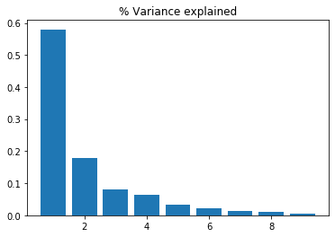

```python
pca = PCA(n_components=9)
pca.fit(x)
xpca = pca.transform(x)
print("Total variance explained", round(np.sum(pca.explained_variance_ratio_)*100,2))
x_train, x_test, y_train, y_test = train_test_split(xpca, y, test_size = 0.25, random_state = 100)
print("Variance explained by individual components", np.round(pca.explained_variance_ratio_*100,2))
plt.title("% Variance explained")
plt.bar(list(range(1,10)), pca.explained_variance_ratio_)
```

#### We now run an SVC to see if the accuracy is better with 9 PCA axes

```python
svc_ = GridSearchCV(SVC(class_weight = "balanced"), param_grid = param_grid, cv = 3, verbose=True)
svc_.fit(x_train, y_train)
y_pred = svc_.predict(x_test)
print("Best parameters", svc_.best_params_)
print(classification_report(y_test, y_pred))
print("Accuracy is:" , round(svc_.score(x_test,y_test) * 100,2))
```

```
Fitting 3 folds for each of 75 candidates, totalling 225 fits
```

```
[Parallel(n_jobs=1)]: Using backend SequentialBackend with 1 concurrent workers.
```

```
Best parameters {'C': 90, 'break_ties': True, 'class_weight': 'balanced', 'decision_function_shape': 'ovr', 'gamma': 0.8}
              precision    recall  f1-score   support

         bus       0.96      0.96      0.96        52
         car       0.99      0.95      0.97       100
         van       0.94      1.00      0.97        58

    accuracy                           0.97       210
   macro avg       0.96      0.97      0.97       210
weighted avg       0.97      0.97      0.97       210

Accuracy is: 96.67
```

```
[Parallel(n_jobs=1)]: Done 225 out of 225 | elapsed:    1.4s finished
```

```
Range of Results [ 92.86  94.05  95.24  95.24  96.39  96.43  96.43  97.62  98.81 100.  ]
Results Accuracy: 96.31 %
Results Std: 2.02 %
95% confidence range 92.26 - 100
```

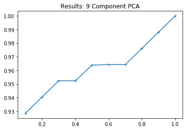

```python
num_fold = 10
kfold = KFold(n_splits=num_fold, shuffle = True, random_state = 100)

svc_kfold = SVC(C = 90, class_weight = "balanced", gamma = 0.8, kernel = "rbf", decision_function_shape="ovr", break_ties=True)
kfold_result_9_pca = cross_val_score(svc_kfold, xpca, y, cv = kfold)
kfold_result_9_pca = np.sort(kfold_result_9_pca)
print("Range of Results", np.round(kfold_result_9_pca*100,2))
perc_accuracy = kfold_result_9_pca.mean()*100
std_dev = kfold_result_9_pca.std()*100
print ("Results Accuracy:", round(perc_accuracy,2),"%")
print ("Results Std:", round(std_dev,2), "%")
min_range = round((perc_accuracy - 2*std_dev),2)
max_range = round((perc_accuracy + 2*std_dev),2)
if min_range < 0:
    min_range = 0
if max_range > 100:
    max_range = 100
print ("95% confidence range", min_range, "-", max_range)
plt.plot((np.array(range(1, 11))/10),kfold_result_9_pca, marker = "+")
plt.title("Results: 9 Component PCA")
```

#### Despite reducing half the axes, the overall accuracy drop is only around 2% - 3%. If performance was a concern, 9 components would perform well enough to put into production

## Q8 Compare the accuracy scores and cross validation scores of Support vector machines – one trained using raw data and the other using Principal Components, and mention your findings

## Ans8

### We compare the individual accuracies, deviations and plot the curves for each SVC

```
<BarContainer object of 4 artists>
```

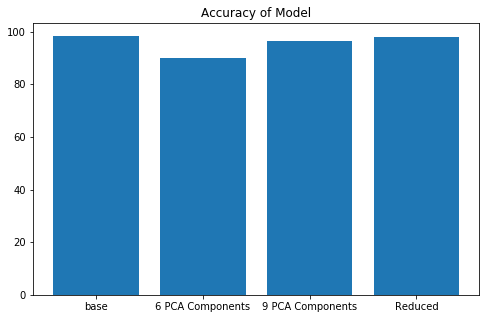

```python
plt.figure (figsize = (8,5))
plt.title("Accuracy of Model")
plt.bar (["base","6 PCA Components","9 PCA Components","Reduced"], [kfold_result.mean()*100,kfold_result_6_pca.mean()*100,kfold_result_9_pca.mean()*100, kfold_result_reduced.mean()*100])
```

```
<BarContainer object of 4 artists>
```

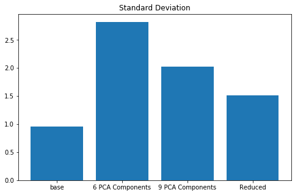

```python
plt.figure (figsize = (8,5))
plt.title("Standard Deviation")
plt.bar (["base","6 PCA Components","9 PCA Components", "Reduced"], [kfold_result.std()*100,kfold_result_6_pca.std()*100,kfold_result_9_pca.std()*100, kfold_result_reduced.std() * 100])
```

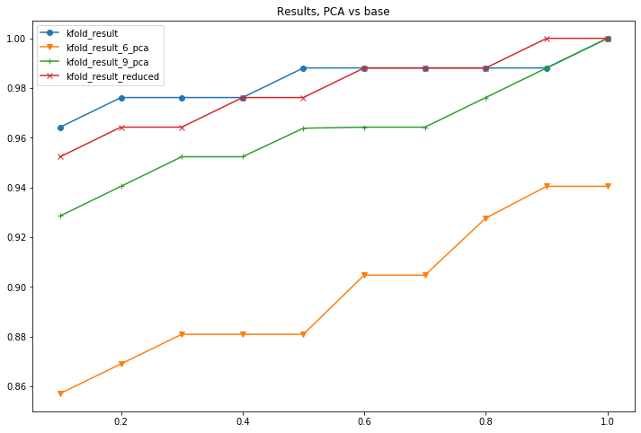

```python
plt.figure (figsize = (12,8))
plt.plot((np.array(range(1, 11))/10),kfold_result, label = "kfold_result", marker = "o")
plt.plot((np.array(range(1, 11))/10),kfold_result_6_pca, label = "kfold_result_6_pca", marker = "v")
plt.plot((np.array(range(1, 11))/10),kfold_result_9_pca, label = "kfold_result_9_pca", marker = "+")
plt.plot((np.array(range(1, 11))/10),kfold_result_reduced, label = "kfold_result_reduced", marker = "x")

plt.title("Results, PCA vs base")
plt.legend(loc = "best")
```

#### The PCA with only 9 Axes performs just a bit worse than the base variation of SVC which worked on 18 columns. The 6 component PCA however is significantly further away. It is interesting to note that the variant with dropped columns performs almost on par with the variant with full data. What could be a topic of experimentation is what columns to drop. Should we drop at correlation 85%, 80% or 95%?